# Predict COVID-19 Cases Using Synthetic Controls

We modify the Synthetic Control methodology commonly used for policy evaluation. Synthetic Control generates a credible synthetic counterfactual to the treated unit by taking a weighted combination among the pool of untreated units that minimizes the difference between the treated and synthetic unit during the pre-treatment period.

Our data for COVID-19 cases is drawn from the [Corona Data Scraper (CDS)](https://coronadatascraper.com/#home). CDS pulls COVID-19 Coronavirus case data from verified sources, finds the corresponding GeoJSON features, and adds population data. Data sources are given for each observation. We focus on datapoints from the United States aggregated at the county level, which corresponds to our focal unit.

```r
cases_scrape = read.csv(url('https://coronadatascraper.com/timeseries.csv')) %>% as.data.table()
cases_scrape = cases_scrape[country %in% c('USA', 'United States')  & level == 'county' & county != '' & aggregate =='county', !c('url', 'tz')]
head(cases_scrape)
```

| name | level | city | county | state | country | population | lat | long | aggregate | cases | deaths | recovered | active | tested | growthFactor | date |
| --- | --- | --- | --- | --- | --- | --- | --- | --- | --- | --- | --- | --- | --- | --- | --- | --- |
| Kitsap County, Washington, United States | county |  | Kitsap County | Washington | United States | 271473 | 47.67204 | -122.7434 | county | 1 | NA | NA | 1 | NA | NA | 2020-03-10 |
| Kitsap County, Washington, United States | county |  | Kitsap County | Washington | United States | 271473 | 47.67204 | -122.7434 | county | 2 | NA | NA | 2 | NA | 2.0 | 2020-03-11 |
| Kitsap County, Washington, United States | county |  | Kitsap County | Washington | United States | 271473 | 47.67204 | -122.7434 | county | 2 | NA | NA | NA | NA | 1.0 | 2020-03-12 |
| Kitsap County, Washington, United States | county |  | Kitsap County | Washington | United States | 271473 | 47.67204 | -122.7434 | county | 3 | NA | NA | NA | NA | 1.5 | 2020-03-13 |
| Kitsap County, Washington, United States | county |  | Kitsap County | Washington | United States | 271473 | 47.67204 | -122.7434 | county | 3 | NA | NA | NA | NA | 1.0 | 2020-03-14 |
| Kitsap County, Washington, United States | county |  | Kitsap County | Washington | United States | 271473 | 47.67204 | -122.7434 | county | 3 | NA | NA | NA | NA | 1.0 | 2020-03-15 |

Additionally, we utilize the Johns Hopkins database for robustness checks and as an additional source for matching county names and identifiers

```r
read.csv(url('https://raw.githubusercontent.com/cchen-ops/COVID-19-Synthetic-Control-Forecast/master/confirmed-US.csv')) %>% as.data.table() -> casesJHU

# Cast data from wide to long
casesJHU = melt(casesJHU, id.vars = c("ï..UID", "iso2", "iso3", "code3", "FIPS", "Admin2", "Province_State", "Country_Region", "Lat", "Long_", "Combined_Key"), variable.name = 'Date')

# Keep only data at the county-level
casesJHU[, FIPS_length := nchar(FIPS)]
casesJHU = casesJHU[ FIPS_length >= 4 ]

# Convert Date to usable form
casesJHU[, Date := as.character(Date)]
casesJHU[, Date := gsub('X', '', Date)]
casesJHU[, Date := mdy(Date)]
```

County demographics and charateristics are drawn from the Health Resources & Services Administration’s Area Health Resource Files [(AHRF)](https://data.hrsa.gov/data/download) at the county level.

The AHRF provides current as well as historic data for more than 6,000 variables for each of the nation’s counties, as well as state and national data. It contains information on health facilities, health professions, measures of resource scarcity, health status, economic activity, health training programs, and socioeconomic and environmental characteristics. In addition, the basic file contains geographic codes and descriptors which enable it to be linked to many other files and to aggregate counties into various geographic groupings.

The Area Health Resources Files (AHRF) data are designed to be used by planners, policymakers, researchers, and others interested in the nation’s health care delivery system and factors that may impact health status and health care in the United States. The AHRF data includes county, state, and national-level files in eight broad areas: Health Care Professions, Health Facilities, Population Characteristics, Economics, Health Professions Training, Hospital Utilization, Hospital Expenditures, and Environment. The AHRF data are obtained from more than 60 sources. The AHRF has county, state, and national level files from the HRSA, Bureau of Health Workforce (BHW) available for download.

```r
read.csv(file = 'C:\\Users\\Workstation\\Box\\Indiana Research\\COVID-19\\SynthCon\\ahrf2019.csv') %>% as.data.table() -> ahrf
setnames(ahrf, 'f00002', 'fips')
ahrf[, FIPS_length := nchar(fips)]
```

Data on stay-at-home orders are drawn from New York Times [interactive tool](https://www.nytimes.com/interactive/2020/us/coronavirus-stay-at-home-order.html) on current stay-ay-home orders. The orders are often issued at the state level, but are sometimes preceded by county-level orders. As such, the exact effective date may vary depending on the granularity. For this analysis, state-level orders are taken as the default date of policy intervention. In the absence of such orders, county or city level orders of large population centers are used as a proxy for state-level intervention. The effective date is chosen in an ad-hoc manner among all orders within the state with emphasis given to earlier orders and those for large population centers. Future versions may include refinement of the exact order dates at the county level.

```r
read.csv(url('https://raw.githubusercontent.com/cchen-ops/COVID-19-Synthetic-Control-Forecast/master/ShelterOrders.csv')) %>% as.data.table() -> shelter
setnames(shelter, 'ï..State', 'state')
shelter[, firstshelter := mdy(First)]
```

Data in the AHRF are organized by Federal Information Processing Standards (FIPS) code, which uniquely identifies counties and county equivalents in the United States, certain U.S. possessions, and certain freely associated states. Merging the COVID-19 data with AHRF requires matching county names to their corresponding FIPS. As the names are largely standardized across sources, simple matching and cleaning techniques are effective for almost all counties. Manaul cleaning is implemented on the remaining unpair counties. Note that some data is excluded during the matching process. Data may be reported at both the individual county level as well as at the economic area level, which consists of multiple counties. For example, Alaska reports data both for Anchorage county as well as the Anchorage Economic Area. Only the former data is kept.

```r
# Get FIPS
FIPS_list = read.csv(url('https://raw.githubusercontent.com/cchen-ops/COVID-19-Synthetic-Control-Forecast/master/countyfipstool20190120.csv')) %>% as.data.table()
FIPS_list[, cname1 := tolower(cname)]
FIPS_list = FIPS_list[, c('sname', 'sab', 'cname1', 'fips')] %>% unique()

state_names = cbind(state.abb, state.name)
state_names = rbind(state_names, c('DC', 'District of Columbia')) %>% as.data.table()

cases_scrape1 = cases_scrape[county != '(unassigned)']

cases_scrape1[, county1 := county]
cases_scrape1[, county1 := gsub(' County', '', county1)]
cases_scrape1[, county1 := gsub(' City', '', county1)]
cases_scrape1[, county1 := gsub(' Parish', '', county1)]
cases_scrape1[, county1 := gsub(' Municipality', '', county1)]
cases_scrape1[, county1 := gsub(' Borough', '', county1)]
cases_scrape1[, county1 := gsub(' Census Area', '', county1)]
cases_scrape1[, county1 := gsub('\'', '', county1)]

cases_scrape1[, county1 := ifelse(county == 'Kansas City' & state %in% as.vector(state_names[state.abb == "MO"]), 'Kansas City', county1)]
cases_scrape1[, county1 := ifelse(county == 'Baltimore City' & state %in% as.vector(state_names[state.abb == "MD"]), 'Baltimore City', county1)]
cases_scrape1[, county1 := ifelse(county == 'St. Louis City' & state %in% as.vector(state_names[state.abb == "MO"]), 'St. Louis City', county1)]
cases_scrape1[, county1 := ifelse(county == 'Carson City' & state %in% as.vector(state_names[state.abb == "NV"]), 'Carson City', county1)]
cases_scrape1[, county1 := ifelse(county == 'Charles City' & state %in% as.vector(state_names[state.abb == "VA"]), 'Charles City', county1)]
cases_scrape1[, county1 := ifelse(county1 == 'Charles' & state %in% as.vector(state_names[state.abb == "VA"]), 'Charles City', county1)]
cases_scrape1[, county1 := ifelse(county == 'James City' & state %in% as.vector(state_names[state.abb == "VA"]), 'James City', county1)]
cases_scrape1[, county1 := ifelse(county1 == 'James' & state %in% as.vector(state_names[state.abb == "VA"]), 'James City', county1)]
cases_scrape1[, county1 := ifelse(county == 'Fairfax City' & state %in% as.vector(state_names[state.abb == "VA"]), 'Fairfax City', county1)]
cases_scrape1[, county1 := ifelse(county == 'Franklin City' & state %in% as.vector(state_names[state.abb == "VA"]), 'Franklin City', county1)]
cases_scrape1[, county1 := ifelse(county == 'Richmond City' & state %in% as.vector(state_names[state.abb == "VA"]), 'Richmond City', county1)]
cases_scrape1[, county1 := ifelse(county == 'Roanoke City' & state %in% as.vector(state_names[state.abb == "VA"]), 'Roanoke City', county1)]
cases_scrape1[, county1 := ifelse(county1 == 'Lac Qui Parle' & state %in% as.vector(state_names[state.abb == "MN"]), 'Lac qui Parle', county1)]
cases_scrape1[, county1 := ifelse(county1 == 'LeSeur' & state %in% as.vector(state_names[state.abb == "MN"]), 'Le Sueur', county1)]
cases_scrape1[, county1 := ifelse(county1 == 'Filmore' & state %in% as.vector(state_names[state.abb == "MN"]), 'Fillmore', county1)]
cases_scrape1[, county1 := ifelse(county1 == 'La Salle' & state %in% as.vector(state_names[state.abb == "LA"]), 'LaSalle', county1)]
cases_scrape1[, county1 := ifelse(county1 == 'DoÃ±a Ana' & state %in% as.vector(state_names[state.abb == "NM"]), 'Dona Ana', county1)]
cases_scrape1[, county1 := ifelse(county1 == 'Adam' & state %in% as.vector(state_names[state.abb == "ID"]), 'Adams', county1)]
cases_scrape1[, county1 := ifelse(county1 == 'Dekalb' & state %in% as.vector(state_names[state.abb == "TN"]), 'DeKalb', county1)]

cases_scrape1[, county1 := tolower(as.character(county1))]

cases2 = merge(cases_scrape1, FIPS_list[, !c('sab')], by.x = c('county1', 'state'), by.y = c('cname1', 'sname'), all.x = T)

# Utilize the Johns Hopkins Data for additional matches
FIPS_list2 = casesJHU[Admin2 != "" & !is.na(FIPS) & FIPS_length >=4 , c('FIPS', 'Admin2', 'Province_State'), with = F] %>% unique()
setnames(FIPS_list2, c('Admin2', 'Province_State'), c('county', 'state'))

state_names = cbind(state.abb, state.name)
state_names = rbind(state_names, c('DC', 'District of Columbia')) %>% as.data.table()
FIPS_list2 = merge(FIPS_list2, state_names, by.x = 'state', by.y = 'state.name')

FIPS_list2[, county1 := tolower(county)]
cases2 = merge(cases2, FIPS_list2[, !c('county', 'state.abb')], by.x = c('county1', 'state'), by.y = c('county1', 'state'), all.x = T)
cases2[, fips := ifelse(is.na(fips) & !is.na(FIPS), FIPS, fips)]

cases2 = cases2[!is.na(fips), !c('FIPS', 'county1', 'name', 'level', 'city', 'lat', 'long', 'aggregate', 'country')]
cases2[, date := ymd(date)]
```

The methodology is able to accommodate a variety of measures. Currently, the most common measures of interest are the cummulative number of cases and deaths. In this proof-of-concept, we look at predicting COVID-19 cases for Marion County, which includes the Indianapolis metropolitan area. The county of interest is indicated by its respective FIPS code. Regions can also be defined as a grouping of counties.

We synchronize the evolution of COVID-19 in counties across the US based on the first date on which the n$^{th}$ case was confirmed within the county, where $n \in {10, 25, 50}$. The reasoning is that the initial cases potentially occur at random and is not symptomatic of the COVID-19 taking hold within the community. An isolated case can occur very early on due to random arrivals. We chose to analyze the date of the 25$^{th}$ case as the synchronizing event.

```r
# Set variable of interest
target_var = 'cases'
target_cty = '18097' # Marion County (Indianapolis)
synch_event = 25

cases2[, value := get(target_var)]

cases2[, c('fips', 'date', 'value')] %>% group_by(fips) %>% filter(value >= synch_event) %>% arrange(date) %>% mutate(sync_Date = min(date)) %>% as.data.table() -> case_sync

cases2 = merge(cases2, case_sync[, c('fips', 'sync_Date'), with = F] %>% unique(), by = c('fips'), all.x = T)
cases2[, daysFromSync := ifelse(!is.na(sync_Date), date - sync_Date, NA)]

cases_sub = cases2[!is.na(sync_Date)]

focal_county = cases_sub[fips == target_cty]

cases_candidates = cases_sub[sync_Date < focal_county[!is.na(sync_Date)]$sync_Date %>% unique()]$fips  %>% unique()
print(paste0('Number of Candidate Counties: ', cases_candidates %>% length()))
```

```
[1] "Number of Candidate Counties: 67"
```

The synchronizing event defines a pool of counties that are comparable to our focal county by identifying those where the n$^{th}$ case occured prior to the date in our focal county. We include additional variables in order to allow for the most comparable comparsion based on not only the evolution of COVID-19, but also county characteristics. The pool of control variables is drawn from the AHRF and was chosen to demographics, health resources, and level of urbanization in mind. The variables are then standardized by population in order to make comparisons across counties of potentially different sizes.

```r
#Candidate fields of Interest
#f1198418 - Pop Estimate
#f1390617 - Pop Male
#f1348310 - Med Age
#f1484010 - Pop 65+
#f1491610 - % Urban Pop
#f1491710 - Census Urban Pop
#f1492010 - Census Rural Pop
#f1139619 - Veteran Pop
#f0874510 - Number of households
#f1351310 - Average Household size
#f0524210 - Pop in Group Quarters
#f1193515 - 3yr influenza
#f1193615 - 3yr chronic lower resp
#f0978117 - Per capital income
#f1434513 - Median household income
#f1332117 - % persons in poverty
#f1549517 - persons 18-64
#f1526618 - % Good air quality days
#f1459113 - #16+ workers Public transport
#f1457213 - #16+ workers
#f0886817 - tot # hospitals
#f1404917 - Nursing Home Beds
#f1321118 - # Skilled nursing facilities
#f1321518 - # nursing facilities



ahrf_sub = ahrf[FIPS_length >= 4, c('fips', 'f1198418', 'f1390617', 'f1348310', 'f1484010', 'f1491610', 'f1491710', 'f1492010', 'f1139619', 'f0874510', 'f1351310', 'f0524210', 'f1193515', 'f1193615', 'f0978117', 'f1434513', 'f1332117', 'f1549517', 'f1526618', 'f1459113', 'f1457213', 'f0886817', 'f1404917', 'f1321118', 'f1321518')]

setnames(ahrf_sub,
         c('f1198418', 'f1390617', 'f1348310', 'f1484010', 'f1491610', 'f1491710', 'f1492010', 'f1139619', 'f0874510', 'f1351310','f0524210', 'f1193515', 'f1193615', 'f0978117', 'f1434513', 'f1332117', 'f1549517', 'f1526618', 'f1459113' , 'f1457213', 'f0886817', 'f1404917', 'f1321118', 'f1321518'),
         c('pop', 'pop_male', 'age_med', 'pop_65', 'urb_pct', 'pop_urb', 'pop_rur', 'pop_vet', 'hh_num', 'hh_avg', 'pop_grpqrt', 'flu_3', 'rep_3', 'inc_per', 'inc_med', 'pov_pct', 'pop_1864', 'goodair_pct', 'trans_pub_work', 'workers', 'hosp', 'nf_beds', 'snf', 'nf'))

ahrf_sub[, pop_male_pct := pop_male / pop]
ahrf_sub[, pop_65_pct := pop_65 / pop]
ahrf_sub[, pop_vet_pct := pop_vet / pop]
ahrf_sub[, pop_grp_pct := pop_grpqrt / pop]
ahrf_sub[, pop_1864_pct := pop_1864 / pop]
ahrf_sub[, trans_pub_pct := trans_pub_work / workers]
ahrf_sub[, pop_hosp := pop / hosp]
ahrf_sub[, flu_pct := flu_3 / pop]
ahrf_sub[, rep_pct := rep_3 / pop]

#Good air is missing and so is flu.
```

We include policy interventions, specifically the issuance of shelter-in-place orders. The intervention is parameterized in three ways i) binary variable at the county-day level; ii) difference between the day of intervention and the reporting date; iii) the days since the policy was implemented.

```r
# Merge data, but remove the cruise ships and other non-counties
synthdat = merge(cases_sub[fips %in% c(cases_candidates[!cases_candidates %in% c('99999', '88888')], '18097') ], ahrf_sub, by = 'fips', all.x = T)

synthdat = merge(synthdat, shelter[, c('Name', 'firstshelter')], by.x = 'state', by.y = 'Name', all.x = T)

# Parameterize Shelter variable
# i) whether there is a shelter order in place at the time of the observation
synthdat[, shelter := 0]
synthdat[, shelter := ifelse(!is.na(firstshelter)& firstshelter <= date, 1, shelter)]

# ii) number of days since the shelter order in place at the time of the observation
synthdat[, sheltersince := 0]
synthdat[, sheltersince := ifelse(!is.na(firstshelter), date - firstshelter, sheltersince)]

# iii) number of days since the shelter order in place at the time of the observation with a minimum of 0
synthdat[, sheltersince0 := ifelse(sheltersince < 0 , 0, sheltersince)]
```

In order to provide forecasts, we restrict the pool of controls to those counties that experienced the outbreak at least $x$ days prior to our focal county. Forecasting requires data from the comparable counties and thus cannot predict beyond the largest number of days since the n$^{th}$ synchronizing case. Below we require control counties to have at least 1 additional day.

```r
## Prepare the data for Synthetic Control

# Decide minimum observations
extra_obs = 1
min_obs = (synthdat[fips == target_cty]$daysFromSync %>% max()) + 1 + extra_obs

# Select subset of variables
temp = synthdat[!is.na(daysFromSync) & daysFromSync >= 0, c('fips', 'daysFromSync', 'value', 'pop', 'pop_male_pct', 'age_med', 'pop_65_pct', 'urb_pct', 'pop_vet_pct', 'hh_avg', 'pop_grp_pct', 'rep_pct', 'inc_med', 'pov_pct', 'pop_1864_pct', 'trans_pub_pct', 'pop_hosp', 'snf', 'nf', 'shelter', 'sheltersince', 'sheltersince0', 'growthFactor')]

# Synth needs both a numerical and character identifier for each county. Character identifier is the label
temp[, fips := as.character(fips)]
temp[, idid := as.numeric(fips)]

temp[daysFromSync <= min_obs - 1] %>% group_by(fips) %>% summarise(n = sum(!is.na(fips))) %>% filter(n < min_obs) -> missing

# Incorporate all possible counties and the focal county
temp = temp[(!fips %in% missing$fips) | fips == target_cty]

temp[, pop := as.numeric(pop)]
temp[, value := as.numeric(value)]
temp[, daysFromSync := as.numeric(daysFromSync)]


testdiff = 0
dataprep.out<-
  dataprep(
    foo = temp[daysFromSync <= (temp[idid == target_cty]$daysFromSync %>% max())],
    predictors = c('pop_male_pct', 'age_med', 'pop_65_pct', 'pop_vet_pct', 'pov_pct', 'trans_pub_pct', 'sheltersince0', 'hh_avg', 'inc_med', 'pop_hosp'),
    predictors.op = "mean",
    dependent = 'value',
    time.variable = "daysFromSync",
    unit.variable = 'idid',
    treatment.identifier = target_cty,
    controls.identifier = setdiff(temp[daysFromSync <= (temp[idid == target_cty]$daysFromSync %>% max())]$idid %>% unique(), target_cty),
    time.predictors.prior = c(0:(temp[idid == target_cty]$daysFromSync %>% max()-testdiff)),
    time.optimize.ssr = c(0:(temp[idid == target_cty]$daysFromSync %>% max()-testdiff)),
    unit.names.variable = "fips",
    time.plot = c(0:(temp[idid == target_cty]$daysFromSync %>% max()))
  )
# Very good results c('pop_male_pct', 'age_med', 'pop_vet_pct', 'pop_grp_pct', 'pov_pct', 'trans_pub_pct'),
#    predictors = c('pop_male_pct', 'pop_65_pct', 'pov_pct', 'trans_pub_pct'),
```

We implement synthetic controls and generate the best fit.

Synthetic controls find the weighting across control counties that minimizes the difference across both the target and control variables. We examine both the counties that make up the best-fit as well as their predicted COVID-19 measure.

```r
# transform(dataprep.out$Y1plot-(dataprep.out$Y0plot%*%synth.out$solution.w))
tt = as.data.frame(synth.out$solution.w)
tt = setDT(tt, keep.rownames = TRUE)
tt = tt[order(-w.weight)]
tt[, rn := as.integer(rn)]

#Show the top comparable counties and their respective percentages (< 5%)
comps = merge(tt[w.weight > 0.05], casesJHU[, c('FIPS', 'Admin2', 'Province_State')] %>% unique(), by.x = 'rn', by.y = 'FIPS')
setnames(comps, c('Admin2', 'Province_State', 'w.weight'), c('County', 'State', 'Weight'))
comps = comps[order(-Weight)]
print("Most comparable counties:")
```

```
[1] "Most comparable counties:"
```

```r
print(comps[, c('County', 'State', 'Weight')])
```

| County | State | Weight |
| --- | --- | --- |
| Milwaukee | Wisconsin | 0.3995335 |
| Ocean | New Jersey | 0.3115701 |
| Philadelphia | Pennsylvania | 0.1407024 |
| Wayne | Michigan | 0.1180343 |

```r
#Show Predictions
# print('Predictions')
# structure((dataprep.out$Y0plot%*%synth.out$solution.w) %>% as.vector(),  names = synthdat[fips == target_cty & daysFromSync >= 0]$date %>% as.character()) %>% print()

#Build predictions beyond current data if there is enough data to cover at least 90% of the weights
pred = c()
grwth = c()
for(d in 0:extra_obs){
  daysFromSyncF = d + min(min_obs, temp[idid == target_cty]$daysFromSync %>% max())

  temp_case = merge(cases_sub[daysFromSync == daysFromSyncF], tt, by.x = 'fips', by.y = 'rn')
  if(sum(temp_case$w.weight) < 0.9){
    pred = c(pred, NA)
  } else {
    temp_case[, w.weight_adj := w.weight / sum(temp_case$w.weight)]
    pred = c(pred, crossprod(temp_case$value, temp_case$w.weight_adj))
    grwth = c(grwth, crossprod(temp_case$growthFactor, temp_case$w.weight_adj))
  }
}
# pred
# grwth

#Show Predictions
predTab = cbind((dataprep.out$Y0plot%*%synth.out$solution.w) %>% as.vector(), (synthdat[fips == target_cty & daysFromSync >= 0]$date %>% as.character()))
predTab = rbind(predTab, cbind(pred[2:length(pred)], as.character((synthdat[fips == target_cty & daysFromSync >= 0]$date %>% max()) + seq(1, length(pred) - 1, 1))))
predTab = as.data.table(predTab)
setnames(predTab, c('V1', 'V2'), c(target_var, 'Date'))
print(predTab)
```

| cases | Date |
| --- | --- |
| 48.5340309035071 | 2020-03-20 |
| 67.5519711858152 | 2020-03-21 |
| 96.6873487252474 | 2020-03-22 |
| 131.588806904753 | 2020-03-23 |
| 178.491571131061 | 2020-03-24 |
| 222.374558161141 | 2020-03-25 |
| 328.12577852582 | 2020-03-26 |
| 461.919637436686 | 2020-03-27 |
| 583.842324679772 | 2020-03-28 |
| 678.938491014441 | 2020-03-29 |

[output cut: 5 more lines]

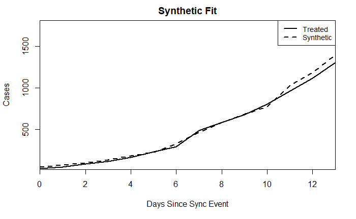

```r
# cases_sub[fips == target_cty & !is.na(daysFromSync)]$value * dataprep.out$Y0plot%*%synth.out$solution.w %>% as.vector()

#Plot the Fit
path.plot(dataprep.res = dataprep.out,synth.res = synth.out, Ylab = 'Cases', Xlab = 'Days Since Sync Event', Main = 'Synthetic Fit')
```

To demonstrate the predictive power of the model, we fit the focal county while holding out $d$ days from the end of the sample where $d \in \{1, 2, 3\}$. We then look at the average deviation in the COVID-19 measure across the hold-out samples.

```r
print('Percentage Error Holdout (1-3):')
```

```
[1] "Percentage Error Holdout (1-3):"
```

```r
print(avggap, digits = 2)
```

```
[1] 0.031 0.015 0.065
```

Additional robutness testing to be completed.